# Stima del numero di decessi dovuti al Covid-19 nel primo trimestre del 2020

Federico De Servi; Marco Peracchi

# Introduzione

Questo lavoro si propone di stimare il numero di decessi dovuti alla pandemia da Covid-19 che ha colpito l’Italia nel primo trimestre 2020. I dataset considerati sono due, disponibili sul sito ISTAT. Il primo è “comune_giorno.csv”, il quale contiene il numero di decessi per ogni comune nel primo trimestre dell’anno 2020. I comuni presenti sono 1689 e sono stati considerati i dati fino al 31 marzo di ogni anno e esclusi eventuali record mancanti. Deve essere specificato che sono stati inclusi all’interno di questo dataset soltanto i comuni che hanno registrato un incremento del 20% della mortalità rispetto alla media nello stesso orizzonte temporale degli anni 2015-2019, ed almeno 10 decessi. Il secondo dataset è “totali_comunali.xlsx”, contenente i decessi registrati in tutti i 7904 comuni italiani dal 2015 al 2019.

```r
#Lettura dati totali relativi a 7904 comuni, anni 2015-2019

totali_15_19 <- read_excel("datasets/totali_comunali.xlsx")

#Lettura dati relativi ai decessi del 2020, per 1689 comuni

totali_20 <- read.csv("datasets/comune_giorno.csv")
```

# Primo metodo

## Stima nazionale

Per fornire un range di valori, abbiamo dapprima calcolato una stima massima di decessi possibili per il 2020. Per i comuni noti abbiamo mantenuto il numero di decessi comunicati dall’ISTAT, mentre per i 6215 comuni ignoti abbiamo ipotizzato lo scenario peggiore: un incremento dei decessi per essi del 20% rispetto alla media dei cinque anni precedenti (considerando ovviamente il primo trimestre per ciascun anno).

```r
#Seleziono solo i dati da gennaio a marzo, escludo i valori mancanti (9999): li stimeremo successivamente

totali_20 %>% filter((GE < 400) & (TOTALE_20 != 9999)) -> dati_20

#Calcolo per ogni comune il numero totale di decessi

dati_20 %>%
  group_by(NOME_COMUNE, NOME_PROVINCIA, NOME_REGIONE) %>%
  summarise_at(vars(TOTALE_20), funs(sum)) -> dati_20
```

```r
#Seleziono soltanto i dati relativi al trimestre gennaio-marzo

totali_15_19 %>% filter(totali_15_19["MESE_DECESSO"] <= 3) -> totali_trimestrali

#Per ogni comune calcolo la media di decessi 15-19 e il relativo incremento del 20% (come da info ISTAT)

totali_trimestrali %>%
  group_by(NOME_COMUNE, NOME_PROVINCIA, NOME_REGIONE) %>%
  summarise_at(vars(DECESSI_2015, DECESSI_2016, DECESSI_2017, DECESSI_2018, DECESSI_2019), funs(sum)) %>%
  rowwise() %>%
  mutate(MEDIA_15_19=mean(c(DECESSI_2015, DECESSI_2016, DECESSI_2017, DECESSI_2018, DECESSI_2019))) %>%
  mutate(INCREMENTO_20_PERC = MEDIA_15_19 + 0.2*MEDIA_15_19) %>%
  select(-DECESSI_2015, -DECESSI_2016, -DECESSI_2017, -DECESSI_2018,-DECESSI_2019) %>%
  mutate(MEDIA_15_19 = floor(MEDIA_15_19), INCREMENTO_20_PERC = ceiling(INCREMENTO_20_PERC)) -> dati_15_19
```

Mediante una merge abbiamo selezionato esclusivamente i 6215 comuni non presenti nel dataset ISTAT.

```r
#Seleziono i comuni mancanti dal dataset ISTAT dati_20 e chiamo il df "dati_non_20"

merge(dati_15_19, dati_20, BY=c("NOME_COMUNE", "NOME_PROVINCIA"), all.x = TRUE) %>%
  filter(is.na(TOTALE_20) == TRUE) %>%
  select(-TOTALE_20) -> dati_non_20
```

Calcoliamo quindi le stime:

```r
#Effettuo il calcolo a livello nazionale

stima_nazionale_max <- sum(dati_20$TOTALE_20) + sum(dati_non_20$INCREMENTO_20_PERC)
stima_nazionale_min <- sum(dati_20$TOTALE_20) + sum(dati_non_20$MEDIA_15_19)
range_decessi <-stima_nazionale_max - stima_nazionale_min
```

La stima superiore rappresenta il caso peggiore, ovvero il caso in cui tutti i comuni di cui non conosciamo i decessi nel primo trimestre 2020 abbiano avuto un incremento dei decessi del 20%, mentre la stima inferiore rappresenta invece l’ipotesi che i decessi siano rimasti gli stessi degli anni passati.

```r
stima_nazionale_max
```

```
[1] 224978
```

```r
stima_nazionale_min
```

```
[1] 194943
```

```r
range_decessi
```

```
[1] 30035
```

## Stima regionale

Abbiamo poi adottato la medesima logica del punto precedente, ma suddividendo i risultati per regione, ottenendo:

```r
#Effettuo il calcolo a livello regionale

dati_20 %>% group_by(NOME_REGIONE) %>% summarise_at(vars(TOTALE_20), funs(sum)) -> t1

dati_non_20 %>% group_by(NOME_REGIONE) %>% summarise_at(vars(MEDIA_15_19, INCREMENTO_20_PERC), funs(sum)) -> t2

merge(t1, t2, BY=NOME_REGIONE) %>% mutate(STIMA_MAX = TOTALE_20 + INCREMENTO_20_PERC, STIMA_MIN = TOTALE_20 + MEDIA_15_19 ) %>%
  select(-TOTALE_20, -INCREMENTO_20_PERC, -MEDIA_15_19) -> range_regionali
```

| NOME_REGIONE | STIMA_MAX | STIMA_MIN |
| --- | --- | --- |
| Abruzzo | 5197 | 4225 |
| Basilicata | 2184 | 1756 |
| Calabria | 7188 | 5752 |
| Campania | 19170 | 15684 |
| Emilia-Romagna | 17560 | 16279 |
| Friuli-Venezia Giulia | 5070 | 4136 |
| Lazio | 19560 | 16109 |
| Liguria | 6876 | 6318 |
| Lombardia | 40543 | 38230 |
| Marche | 6119 | 5286 |
| Molise | 1363 | 1052 |
| Piemonte | 18364 | 15678 |
| Puglia | 13116 | 11120 |
| Sardegna | 5801 | 4785 |
| Sicilia | 18705 | 15514 |
| Toscana | 14397 | 12533 |
| Trentino-Alto Adige/Südtirol | 3362 | 2723 |
| Umbria | 3484 | 2958 |
| Valle d’Aosta/Vallée d’Aoste | 519 | 414 |
| Veneto | 16400 | 14391 |

# Secondo metodo

## Stima nazionale in base alle province

Successivamente si è pensato di stimare in maniera più corretta i decessi, tramite una logica che sfruttasse i dati geografici. Si è ipotizzato che comuni che si trovano nella stessa provincia, avessero un incremento di decessi simile tra di loro. Si è quindi utilizzato l’incremento di decessi per provincia, ottenuto dal dataset “comuni_giorno.csv”, contenente i 1689 comuni che presentavano le caratteristiche di cui si è parlato precedentemente, e lo si è applicato ai comuni i cui decessi andavano stimati, in base alla provincia di appartenenza di ognuno di essi.

```r
#Ora cerchiamo di stimare i decessi applicando l'incremento dei decessi rispetto a 15-19 a livello geografico (provinciale)

#Calcolo gli incrementi per provincia

totali_trimestrali %>%
  select(NOME_COMUNE, PROVINCIA, NOME_PROVINCIA, REGIONE, NOME_REGIONE) %>%
  unique() -> comuni_province

merge(dati_20, dati_15_19, BY=c(NOME_COMUNE, NOME_PROVINCIA), all.x = TRUE) %>%
  select(-INCREMENTO_20_PERC) %>%
  mutate(INCREMENTO_PROV = ((TOTALE_20 - MEDIA_15_19) / TOTALE_20)) %>%
  group_by(NOME_PROVINCIA) %>%
  summarise_at(vars(INCREMENTO_PROV), funs(mean)) -> province_incrementi
```

Durante questo processo ci si è accorti che nel dataset ottenuto mancavano quattro province, si è provveduto ad aggiungerle. Come incremento è stato considerato quello della provincia più prossima.

```r
province_incrementi %>%
  #Per Trieste è stata considerata Gorizia
  add_row(NOME_PROVINCIA = "Trieste", INCREMENTO_PROV = filter(province_incrementi, NOME_PROVINCIA == "Gorizia")$INCREMENTO_PROV) %>%
  #Per Rieti è stata considerata Terni
  add_row(NOME_PROVINCIA = "Rieti", INCREMENTO_PROV = filter(province_incrementi, NOME_PROVINCIA == "Terni")$INCREMENTO_PROV) %>%
  #Per Prato è stata considerata Firenze
  add_row(NOME_PROVINCIA = "Prato", INCREMENTO_PROV = filter(province_incrementi, NOME_PROVINCIA == "Firenze")$INCREMENTO_PROV) %>%
  #Per Bolzano è stata considerata Trento
  add_row(NOME_PROVINCIA = "Bolzano/Bozen", INCREMENTO_PROV = filter(province_incrementi, NOME_PROVINCIA == "Trento")$INCREMENTO_PROV) -> province_incrementi
```

Inserite le province mancanti si è provveduto a calcolare il numero di decessi stimato per ogni comune. Nel caso in cui l’incremento provinciale fosse inferiore al 20%, l’incremento applicato al comune sarebbe quello provinciale, in caso contrario verrebbe effettuata un’ulteriore scelta: se i decessi stimati sono maggiori di 10 allora si considera l’incremento del 20%, altrimenti si utilizza ancora l’incremento provinciale. La motiviazione dietro a questa serie di scelte risiede nel fatto che, se un comune presenta un incremento superiore al 20% e più di 10 decessi, allora si presuppone che sarebbe rientrato all’interno del dataset fornito dall’ISTAT (quello relativo ai 1689 comuni).

```r
merge(dati_non_20, province_incrementi, BY=c(NOME_PROVINCIA), all.x=TRUE) %>%
  mutate(DECESSI_INCREMENTO_PROV = INCREMENTO_PROV*MEDIA_15_19 + MEDIA_15_19, DECESSI_INCREMENTO_PROV = ceiling(DECESSI_INCREMENTO_PROV)) %>%
  mutate(INCREMENTO_ASSEGNATO = ifelse(INCREMENTO_PROV < 0.2 , DECESSI_INCREMENTO_PROV, ifelse(DECESSI_INCREMENTO_PROV > 10, INCREMENTO_20_PERC, DECESSI_INCREMENTO_PROV))) -> incrementi_non_20
```

Per ottenere la stima di decessi totali abbiamo sommato la colonna contenente l’incremento calcolato assegnato con la colonna dei decessi dei 1689 comuni.

```r
stima_decessi <- sum(incrementi_non_20$INCREMENTO_ASSEGNATO) + sum(dati_20$TOTALE_20)
stima_decessi
```

```
[1] 211464
```

Viene poi calcolato l’incremento di decessi rispetto al 2019:

```r
incremento_decessi <- stima_decessi - sum(totali_trimestrali$DECESSI_2019)
incremento_decessi
```

```
[1] 29281
```

## Stima regionale in base alle province

Si calcola ora il numero di decessi suddiviso su base regionale in base alle stime fatte precedentemente, e quindi in base all’incremento provinciale.

```r
dati_20 %>% group_by(NOME_REGIONE) %>%
  summarise_at(vars(TOTALE_20), funs(sum)) -> d1

incrementi_non_20 %>% group_by(NOME_REGIONE) %>%
  summarise_at(vars(INCREMENTO_ASSEGNATO), funs(sum)) -> d2


merge(d1, d2, BY="NOME_REGIONE" ) %>%
  mutate(DECESSI_STIMATI = TOTALE_20 + INCREMENTO_ASSEGNATO) %>%
  select(-TOTALE_20, -INCREMENTO_ASSEGNATO) -> tabella_riepilogativa
```

| NOME_REGIONE | DECESSI_STIMATI |
| --- | --- |
| Abruzzo | 5092 |
| Basilicata | 1957 |
| Calabria | 6853 |
| Campania | 18086 |
| Emilia-Romagna | 16932 |
| Friuli-Venezia Giulia | 4632 |
| Lazio | 16190 |
| Liguria | 6632 |
| Lombardia | 40353 |
| Marche | 5734 |
| Molise | 1309 |
| Piemonte | 17577 |
| Puglia | 11623 |
| Sardegna | 5631 |
| Sicilia | 16589 |
| Toscana | 13615 |
| Trentino-Alto Adige/Südtirol | 3280 |
| Umbria | 3134 |
| Valle d’Aosta/Vallée d’Aoste | 489 |
| Veneto | 15756 |

La tabella evidenzia il numero di decessi stimati per ogni regione nel 2020. Per capire il numero di decessi dovuti al Covid-19 ipotizziamo che quelli **non** dovuti al Covid-19 siano gli stessi del primo trimestre 2019.

```r
totali_trimestrali %>%
  group_by(NOME_REGIONE) %>% summarise_at(vars(DECESSI_2019), funs(sum))-> decessi_regionali_19


merge(tabella_riepilogativa, decessi_regionali_19, BY=NOME_REGIONE) %>%
  mutate(DECESSI_COVID_STIMATI = DECESSI_STIMATI - DECESSI_2019) -> tabella_finale
```

| NOME_REGIONE | DECESSI_STIMATI | DECESSI_2019 | DECESSI_COVID_STIMATI |
| --- | --- | --- | --- |
| Abruzzo | 5092 | 4122 | 970 |
| Basilicata | 1957 | 1934 | 23 |
| Calabria | 6853 | 6138 | 715 |
| Campania | 18086 | 16068 | 2018 |
| Emilia-Romagna | 16932 | 14111 | 2821 |
| Friuli-Venezia Giulia | 4632 | 3951 | 681 |
| Lazio | 16190 | 16465 | -275 |
| Liguria | 6632 | 5899 | 733 |
| Lombardia | 40353 | 28209 | 12144 |
| Marche | 5734 | 4884 | 850 |
| Molise | 1309 | 1093 | 216 |
| Piemonte | 17577 | 14894 | 2683 |
| Puglia | 11623 | 11555 | 68 |
| Sardegna | 5631 | 4789 | 842 |
| Sicilia | 16589 | 15982 | 607 |
| Toscana | 13615 | 12269 | 1346 |
| Trentino-Alto Adige/Südtirol | 3280 | 2635 | 645 |
| Umbria | 3134 | 3001 | 133 |
| Valle d’Aosta/Vallée d’Aoste | 489 | 407 | 82 |
| Veneto | 15756 | 13777 | 1979 |

La colonna DECESSI_COVID_STIMATI contiene il numero di decessi dovuti al Covid-19 nel primo trimestre del 2020.

Vediamo ora graficamente i risultati. Per prima cosa visualizziamo le stime per regione e confrontiamo con la proporzione di dati ufficiali realtivi a 1689 comuni.

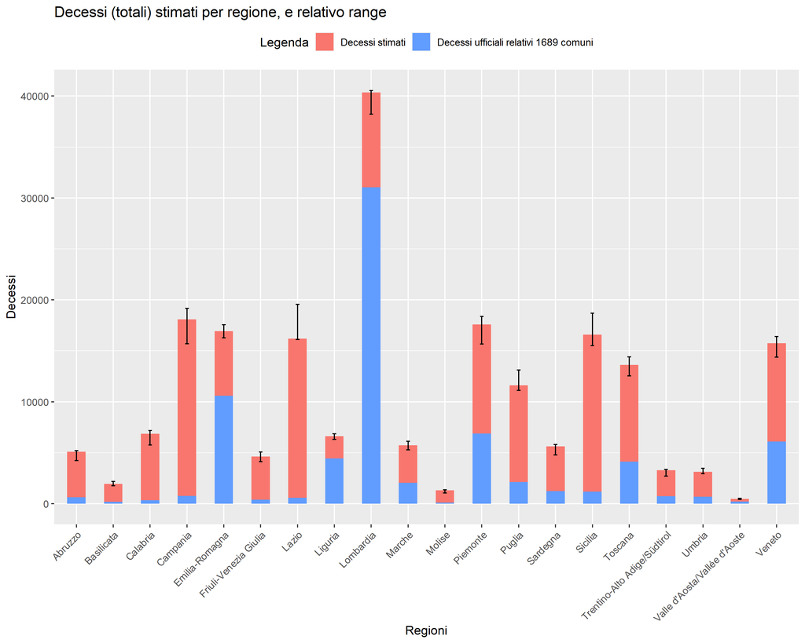

Visualizziamo ora il numero stimato di decessi dovuti a COVID-19.

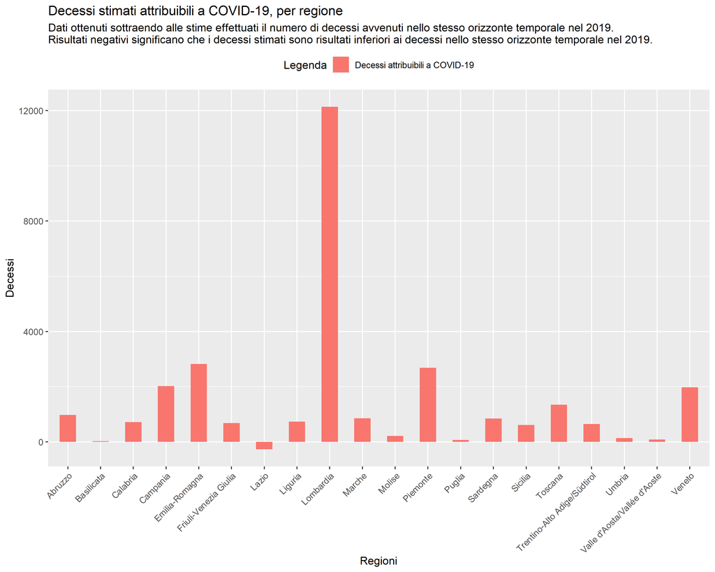

Per comprendere meglio i risultati verifichiamo la percentuale di comuni presenti nel dataset ISTAT per ogni regione.

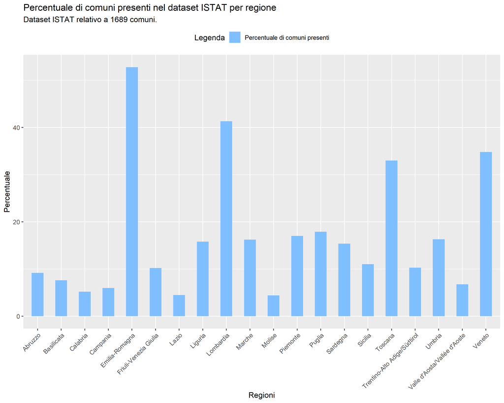

```r
#Ora calcolo e visualizzo il livello di copertura (%di comuni presenti) del dataset, regione per regione

comuni_province %>% group_by(NOME_REGIONE) %>% summarise_at(vars(NOME_COMUNE), funs(NROW)) %>%
  rename(NUMERO_COMUNI_REALE = NOME_COMUNE) -> d3
dati_20 %>%group_by(NOME_REGIONE) %>% summarise_at(vars(NOME_COMUNE), funs(NROW)) %>%
  rename(NUMERO_COMUNI_PRESENTI = NOME_COMUNE)  -> d4

merge(d4, d3, BY = NOME_REGIONE) %>%
  select(NOME_REGIONE, NUMERO_COMUNI_REALE, NUMERO_COMUNI_PRESENTI) %>%
  mutate(COMUNI_PRESENTI_PERC = (NUMERO_COMUNI_PRESENTI /NUMERO_COMUNI_REALE)*100 ) %>%
  mutate(NUMERO_COMUNI_MANCANTI = NUMERO_COMUNI_REALE - NUMERO_COMUNI_PRESENTI) -> copertura_dataset
```

# Confronto con i dati ISTAT del 04/05/2020

Durante questo lavoro l’ISTAT ha aggiornato il dataset aggiungendo dati provenienti da altri comuni, fino a un totale di 6866 comuni. Di conseguenza si è provato a confrontare le stime effettuate precedentemente con i nuovi dati ricevuti.

```r
dati_ufficiali_successivi <- read_excel("datasets/dati_ufficiali_successivi.xlsx")
```

Confrontiamo i dati con le stime regionali ottenute con la logica dell’incremento provinciale.

```r
#Decessi ufficiali per regione (6866 comuni)

dati_ufficiali_successivi %>% group_by(NOME_REGIONE) %>%
  mutate(DECESSI_UFFICIALI = (GENNAIO)+(FEBBRAIO)+(MARZO)) %>%
  summarise_at(vars(DECESSI_UFFICIALI), funs(sum))-> decessi_ufficiali_regioni

#Seleziono gli stessi 6866 comuni dalle nostre stime

merge(incrementi_non_20, dati_ufficiali_successivi, BY=c(NOME_COMUNE, NOME_PROVINCIA)) %>%
  select(-MEDIA_15_19, -INCREMENTO_20_PERC, -INCREMENTO_PROV, -DECESSI_INCREMENTO_PROV,
         -REG, -PROV, -COD_PROVCOM, -GENNAIO, -FEBBRAIO, -MARZO) %>%
  rename(TOTALE_20 = INCREMENTO_ASSEGNATO) -> incremento_non_20_parziali

merge(dati_20, dati_ufficiali_successivi, BY=c(NOME_COMUNE, NOME_PROVINCIA)) %>%
  select(-REG, -PROV, -COD_PROVCOM, -GENNAIO, -FEBBRAIO, -MARZO)-> dati_20_parziali

#E ottengo le nostre stime per i 6866 comuni e creo una tabella riepilogativa parziale (6866 comuni) con le nostre stime

bind_rows(dati_20_parziali, incremento_non_20_parziali) %>% group_by(NOME_REGIONE) %>%
  summarise_at(vars(TOTALE_20), funs(sum)) -> dati_stime_parziali

#Ora ottengo i dati ufficiali e confronto

merge(dati_stime_parziali, decessi_ufficiali_regioni, BY="NOME_REGIONE") %>%
  rename(DECESSI_STIMATI = TOTALE_20) %>%
  mutate(DIFFERENZA_DECESSI = DECESSI_STIMATI - DECESSI_UFFICIALI) -> tabella_riepilogativa_parziale
```

| NOME_REGIONE | DECESSI_STIMATI | DECESSI_UFFICIALI | DIFFERENZA_DECESSI |
| --- | --- | --- | --- |
| Abruzzo | 4343 | 3744 | 599 |
| Basilicata | 1480 | 1339 | 141 |
| Calabria | 5172 | 4392 | 780 |
| Campania | 14287 | 12220 | 2067 |
| Emilia-Romagna | 16039 | 15847 | 192 |
| Friuli-Venezia Giulia | 3154 | 2986 | 168 |
| Lazio | 13086 | 12383 | 703 |
| Liguria | 6077 | 6056 | 21 |
| Lombardia | 39341 | 41733 | -2392 |
| Marche | 4770 | 4673 | 97 |
| Molise | 958 | 780 | 178 |
| Piemonte | 16323 | 15058 | 1265 |
| Puglia | 9881 | 9623 | 258 |
| Sardegna | 4196 | 3719 | 477 |
| Sicilia | 12317 | 11215 | 1102 |
| Toscana | 12035 | 10906 | 1129 |
| Trentino-Alto Adige/Südtirol | 3026 | 2989 | 37 |
| Umbria | 2939 | 2676 | 263 |
| Valle d’Aosta/Vallée d’Aoste | 448 | 433 | 15 |
| Veneto | 13714 | 12859 | 855 |

La tabella ottenuta presenta i decessi stimati confrontati con quelli ufficiali dell’ISTAT e la conseguente differenza. Come svolto precedentemente, calcoliamo nuovamente il numero di decessi da Covid-19 stimato, ipotizzando che il totale non dovuto al virus sia uguale ai decessi del 2019. Si chiarifica che le stime cambiano rispetto alle tabelle precedenti, in quanto, per effettuare un confronto valido, si sono qui considerati soltanto i 6866 comuni presenti anche nel dataset ISTAT del 4 maggio 2020.

```r
totali_trimestrali %>%
  group_by(NOME_COMUNE, NOME_PROVINCIA, NOME_REGIONE) %>%
  summarise_at(vars(DECESSI_2019), funs(sum)) -> df_merge_3

merge(df_merge_3, dati_ufficiali_successivi, BY=c(NOME_COMUNE, NOME_PROVINCIA)) %>%
  select(-COD_PROVCOM, -REG, -PROV, -GENNAIO, -FEBBRAIO, -MARZO) %>%
  group_by(NOME_REGIONE) %>% summarise_at(vars(DECESSI_2019), funs(sum))-> decessi_regionali_19_parziali


merge(tabella_riepilogativa_parziale, decessi_regionali_19_parziali, BY=NOME_REGIONE) %>%
  mutate(DECESSI_COVID_STIMATI = DECESSI_STIMATI - DECESSI_2019) %>% select(-DIFFERENZA_DECESSI, -DECESSI_UFFICIALI)-> tabella_finale_parziale
```

| NOME_REGIONE | DECESSI_STIMATI | DECESSI_2019 | DECESSI_COVID_STIMATI |
| --- | --- | --- | --- |
| Abruzzo | 4343 | 3523 | 820 |
| Basilicata | 1480 | 1447 | 33 |
| Calabria | 5172 | 4652 | 520 |
| Campania | 14287 | 12798 | 1489 |
| Emilia-Romagna | 16039 | 13305 | 2734 |
| Friuli-Venezia Giulia | 3154 | 2755 | 399 |
| Lazio | 13086 | 13371 | -285 |
| Liguria | 6077 | 5420 | 657 |
| Lombardia | 39341 | 27340 | 12001 |
| Marche | 4770 | 4000 | 770 |
| Molise | 958 | 779 | 179 |
| Piemonte | 16323 | 13762 | 2561 |
| Puglia | 9881 | 9828 | 53 |
| Sardegna | 4196 | 3545 | 651 |
| Sicilia | 12317 | 11761 | 556 |
| Toscana | 12035 | 10839 | 1196 |
| Trentino-Alto Adige/Südtirol | 3026 | 2411 | 615 |
| Umbria | 2939 | 2780 | 159 |
| Valle d’Aosta/Vallée d’Aoste | 448 | 368 | 80 |
| Veneto | 13714 | 11970 | 1744 |

Viene visualizzato ora il confronto tra i decessi stimati e gli ultimi dati comunicati dall’ISTAT.

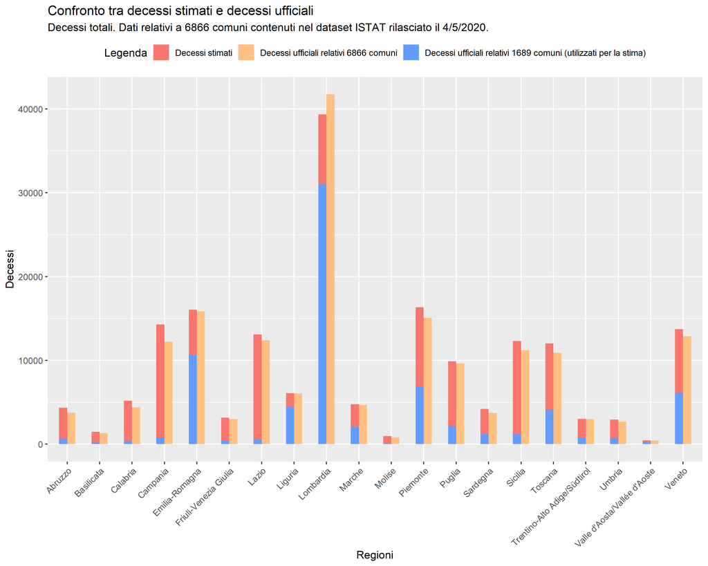